# Human Genome Analysis Lab 11 : Analysis and visualization of your SNP data - Part 2

## IMPORTANT POINTS FOR TODAY’S LAB FOR UNITY USERS

1. `bioconductor` and `gwascat` take a long time to install (20-30 min).
2. The GWAS catalog is getting very large (~250 MB) and difficult to download with intermittent or not fast internet connections. FOR UNITY USERS it is available on Moodle (Github doesn’t allow files greater than 100 MB). Put it in your `data` folder.

## Learning objectives

- Mapping your 23andMe and Ancestry SNP data to phenotypes and the literature using gwascat
- Using GGBIO to map your SNPs
- Creating Manhattan Plots

### Libraries for today’s lab.

Note if you are working on your own computer (and not RStudio Cloud) you will need to install Bioconductor before installing `gwascat`.

```r
# Load Libraries
library(tidyverse)
library(DT)
library(gwascat)
library(ggtext)
library(ggbio)
library(GenomicRanges)
data("CRC", package = "biovizBase")
```

### First load 23andMe or Ancestry data

There are three separate code snippets here. The first is for the 23andMe file that we have been working with. The second is for your 23andME results file which has a hashtag on the column header line. The third is for the AncestryDNA resuts.

#### Code for the 23andMe file that we have been working with.

```r
# Load Files
mySNPs <- read_tsv("data/23andMe_complete.txt", comment = '#',
col_types =
  cols(
    rsid = col_character(),
    chromosome = col_factor(),
    position = col_integer(),
    genotype = col_factor()
  ))
```

#### Code for your 23andMe file if you don’t remove the hashtag on the same line as the column headers.

```r
mySNPs <- read_tsv("data/23andMe_complete.txt", comment = '#', col_names = FALSE) %>%
  setNames(c("rsid","chromosome","position","genotype")) %>%
  mutate(chromosome = as.factor(chromosome)) %>%
  mutate(genotype = as.factor(genotype)) %>%
  mutate(position = as.numeric(position))
```

#### Code for AncestryDNA

```r
# Load Ancestry DNA file
mySNPs <- read_tsv("data/AncestryDNA.txt", comment = '#',
col_types =
  cols(
    rsid = col_character(),
    chromosome = col_factor(),
    position = col_integer()
  )) %>%
  mutate(genotype= paste(allele1, allele2, sep = '')) %>%
  select(-c(allele1, allele2)) %>%
  mutate(across(genotype, as_factor))
```

As we have seen this file holds just the rsid, position, chromosome and genotype

```r
head(mySNPs)
```

```
## # A tibble: 6 × 4
##   rsid       chromosome position genotype
##   <chr>      <fct>         <int> <fct>
## 1 rs4477212  1             82154 AA
## 2 rs3094315  1            752566 AA
## 3 rs3131972  1            752721 GG
## 4 rs12124819 1            776546 AG
## 5 rs11240777 1            798959 AG
## 6 rs6681049  1            800007 CC
```

### Upload the gwas data table

```r
updated_gwas_data <- read_tsv("data/updated_gwas_data.tsv")
```

#### YOU DO NOT NEED TO DO THE NEXT STEP FOR LAB, but To get the most recent data set

To get the catalog into a R data frame.

```r
updated_gwas_data <- as.data.frame(makeCurrentGwascat())
```

Save table in case of internet issues

```r
write_tsv(updated_gwas_data, "data/updated_gwas_data.tsv")
```

### Joining mySNPs with the updated gwas data

```r
mySNPs_gwas_table <- inner_join(mySNPs, updated_gwas_data, by = c("rsid" = "SNPS"))
```

Add columns for your alleles

```r
mySNPs_gwas_table$risk_allele_clean <- str_sub(mySNPs_gwas_table$STRONGEST.SNP.RISK.ALLELE, -1)
mySNPs_gwas_table$my_allele_1 <- str_sub(mySNPs_gwas_table$genotype, 1, 1)
mySNPs_gwas_table$my_allele_2 <- str_sub(mySNPs_gwas_table$genotype, 2, 2)
mySNPs_gwas_table$have_risk_allele_count <- if_else(mySNPs_gwas_table$my_allele_1 == mySNPs_gwas_table$risk_allele_clean, 1, 0) + if_else(mySNPs_gwas_table$my_allele_2 == mySNPs_gwas_table$risk_allele_clean, 1, 0)
```

## Other analyses that can be done with your SNP data

### Example with genome context

#### Bar Plot of Genome Context

```r
# Change CONTEXT to a factor
mySNPs_gwas_table$CONTEXT <- as.factor(mySNPs_gwas_table$CONTEXT)
```

The below code uses the function `fct_infreq` from the `forcats` package in `tidyverse` to order the bars according to abundance.

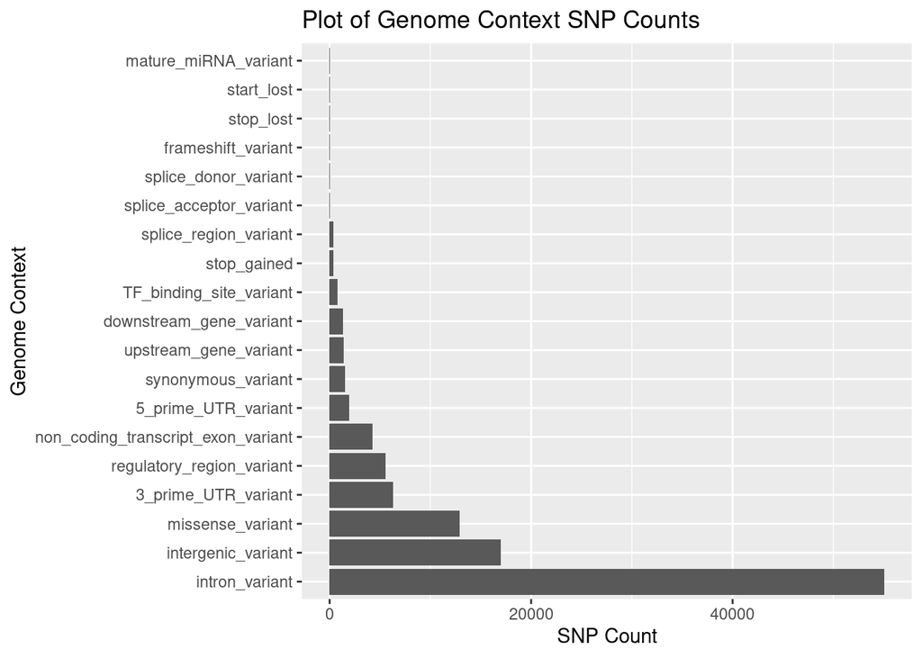

```r
ggplot(mySNPs_gwas_table, aes(x = fct_infreq(CONTEXT))) +
    geom_bar() +
    coord_flip() +
    labs(y = "SNP Count", x = "Genome Context", title="Plot of Genome Context SNP Counts")
```

#### Pie Chart of Genome Context

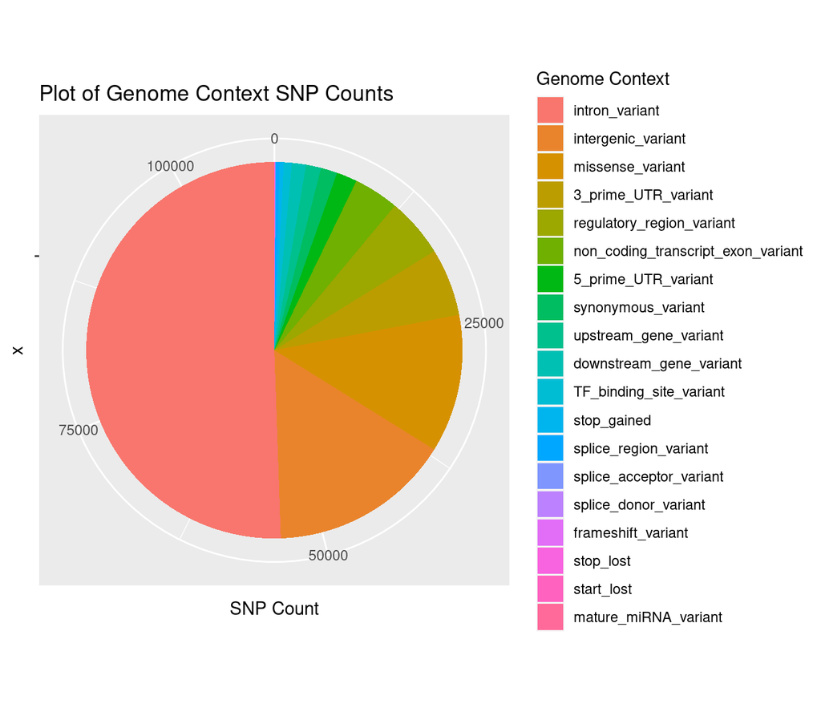

```r
ggplot(mySNPs_gwas_table, aes(x = "", fill = fct_infreq(CONTEXT))) +
    geom_bar(width = 1) +
    coord_polar(theta = "y", start=0) +
    labs(y = "SNP Count", fill = "Genome Context", title="Plot of Genome Context SNP Counts")
```